# Introduction to CSeQTL

Paul Little

Last Refresh: 2025-02-18

# Overview

Assuming all software dependencies and **CSeQTL** (Little et al., 2023) installation are installed, we can begin.

```r
# Load libraries
req_packs = c("ggplot2","smarter","CSeQTL")
for(pack in req_packs){
  library(package = pack,character.only = TRUE)
}

# List package's exported functions
ls("package:CSeQTL")
```

```
#>  [1] "CSeQTL_dataGen"        "CSeQTL_full_analysis"  "CSeQTL_GS"
#>  [4] "CSeQTL_linearTest"     "CSeQTL_oneExtremeSim"  "CSeQTL_run_MatrixEQTL"
#>  [7] "CSeQTL_smart"          "gen_true_RHO"          "OLS_sim"
#> [10] "plot_RHO"              "prep_gene_info"
```

```r
# Fix seed
set.seed(2)
```

# Simulation: No eQTL

We will simulate a dataset with three cell types, reference allele differential expression, and no cell type-specific eQTLs.

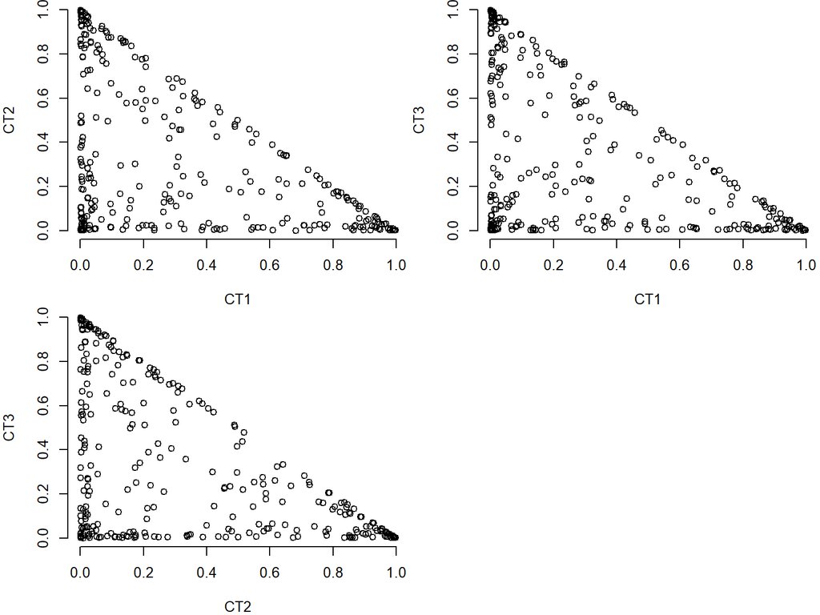

```r
# sample size
NN = 3e2

# fold-change between q-th and 1st cell type
true_KAPPA  = c(1,3,1)

# eQTL effect size per cell type,
#   fold change between B and A allele
true_ETA    = c(1,1,1)

# cis/trans effect size
true_ALPHA  = c(1,1,1)

# count number of cell types
QQ = length(true_KAPPA)

# TReC model overdispersion
true_PHI = 0.1

# ASReC model overdispersion
true_PSI = 0.05

# Simulate cell type proportions
tRHO = gen_true_RHO(wRHO = 1,NN = NN,QQ = QQ)
plot_RHO(RHO = tRHO)
```

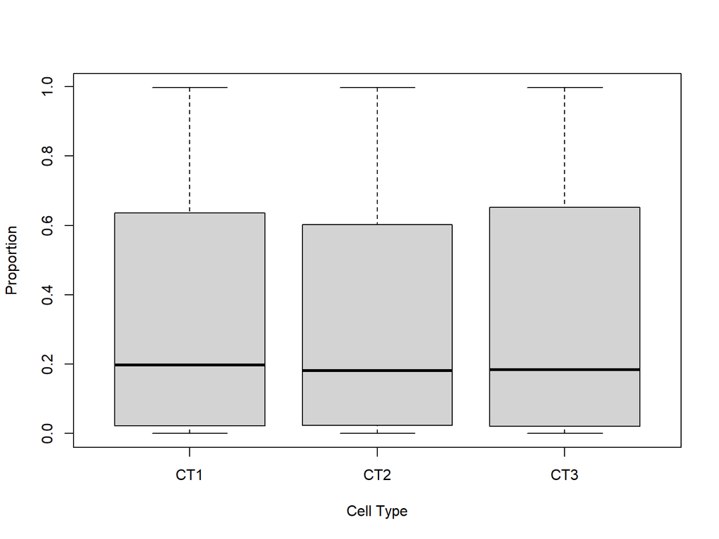

```r
boxplot(tRHO,xlab = "Cell Type",ylab = "Proportion")
```

```r
# Simulate a data object for a gene and SNP
sim = CSeQTL_dataGen(NN = NN,MAF = 0.3,true_BETA0 = log(1000),
  true_KAPPA = true_KAPPA,true_ETA = true_ETA,true_PHI = true_PHI,
  true_PSI = true_PSI,prob_phased = 0.05,true_ALPHA = true_ALPHA,
  RHO = tRHO,cnfSNP = TRUE,show = FALSE)

names(sim)
```

```
#>  [1] "true_PARS" "true_SNP"  "dat"       "XX"        "true_RHO"  "QQ"
#>  [7] "GI"        "np"        "I_np"      "iBETA"     "iPHI"      "MU"
#> [13] "true_OF"   "vname"
```

```r
# TReC, ASReC, haplotype 2 counts
sim$dat[1:3,]
```

```
#>   total     LGX1 total_phased hap2      LBC phased   log_mu        mu  pp
#> 1   456 2339.837           27   13 16.81415      1 6.209945  497.6740 0.5
#> 2  1080 6467.905           47   17 28.63941      1 6.973643 1068.1067 0.5
#> 3   702 3903.057           30   10 17.21821      1 6.566389  710.7982 0.5
#>   phase0 log_lib_size  geno_col
#> 1      0     5.538577 #FF0000BF
#> 2      0     5.850341 #0000FFBF
#> 3      0     5.751526 #00FF00BF
```

```r
# Batch covariates including the intercept
sim$XX[1:3,]
```

```
#>      X1         X2 X3         X4         X5
#> [1,]  1 -1.7890676  1 -0.5523594 1.35690857
#> [2,]  1 -0.6066932  0  1.5950620 1.06844120
#> [3,]  1 -0.9814495  0 -0.9546107 0.06637533
```

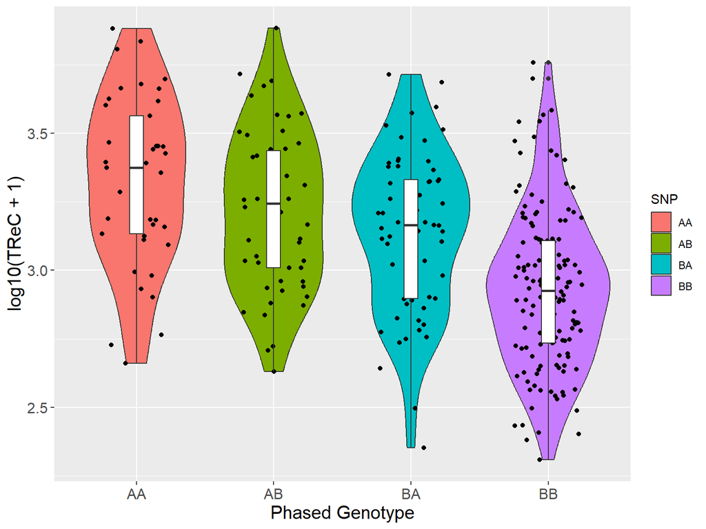

```r
sim$dat$SNP = sim$true_SNP
sim$dat$SNP = factor(sim$dat$SNP,
  levels = sort(unique(sim$dat$SNP)),
  labels = c("AA","AB","BA","BB"))

# TReC vs SNP
ggplot(data = sim$dat,
  mapping = aes(x = SNP,y = log10(total + 1))) +
  geom_violin(aes(fill = SNP)) + geom_jitter(width = 0.25) +
  geom_boxplot(width = 0.1) +
  xlab("Phased Genotype") + ylab("log10(TReC + 1)") +
  theme(legend.position = "right",
    axis.title = element_text(size = 15),
    axis.text = element_text(size = 12))
```

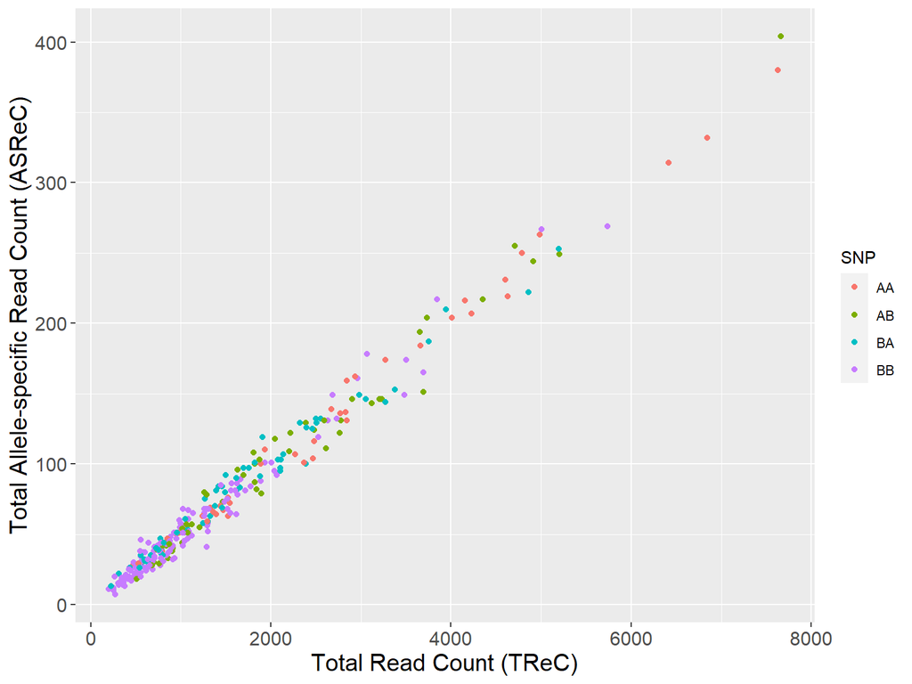

```r
# TReC vs ASReC
ggplot(data = sim$dat,
  mapping = aes(x = total,y = total_phased,color = SNP)) +
  geom_point() + xlab("Total Read Count (TReC)") +
  ylab("Total Allele-specific Read Count (ASReC)") +
  theme(legend.position = "right",
    axis.title = element_text(size = 15),
    axis.text = element_text(size = 12))
```

## CSeQTL

### Bulk Test

Based on the above TReC boxplot, the phased SNP genotype appears to be an eQTL. However, this has yet to account for batch effects. Let us test for a bulk eQTL accounting for batch covariates `sim$XX`. Make sure to center continuous covariates. Notice that CSeQTL, treating bulk TReC as sourced from a single cell type, corresponds to the **TReCASE** (Sun, 2012) method.

```r
summary(sim$XX)
```

```
#>        X1          X2                 X3               X4                 X5
#>  Min.   :1   Min.   :-2.90650   Min.   :0.0000   Min.   :-1.75525   Min.   :-2.48349
#>  1st Qu.:1   1st Qu.:-0.64850   1st Qu.:0.0000   1st Qu.:-0.83890   1st Qu.:-0.65859
#>  Median :1   Median :-0.02574   Median :0.0000   Median : 0.05764   Median :-0.00457
#>  Mean   :1   Mean   : 0.00000   Mean   :0.4833   Mean   : 0.00000   Mean   : 0.00000
#>  3rd Qu.:1   3rd Qu.: 0.68804   3rd Qu.:1.0000   3rd Qu.: 0.85752   3rd Qu.: 0.69906
#>  Max.   :1   Max.   : 2.82172   Max.   :1.0000   Max.   : 1.67543   Max.   : 2.69418
```

```r
mRHO = matrix(1,NN,1)
colnames(mRHO) = "Bulk"
cistrans_thres = 0.01
res = c()

for(trec_only in c(TRUE,FALSE)){
for(neg_binom in c(TRUE,FALSE)){
for(beta_binom in c(TRUE,FALSE)){

  cat(sprintf("%s: trec_only = %s, neg_binom = %s, beta_binom = %s ...\n",
    date(),trec_only,neg_binom,beta_binom))

  PHASE = sim$dat$phased * ifelse(trec_only,0,1)
  upPHI = ifelse(neg_binom,1,0)
  upPSI = ifelse(beta_binom,1,0)

  sout = CSeQTL_smart(TREC = sim$dat$total,hap2 = sim$dat$hap2,
    ASREC = sim$dat$total_phased,PHASE = PHASE,
    SNP = sim$true_SNP,RHO = mRHO,XX = sim$XX,upPHI = upPHI,
    upKAPPA = 1,upETA = 1,upPSI = upPSI,upALPHA = 1,
    iFullModel = FALSE,trim = FALSE,thres_TRIM = 10,
    hypotest = TRUE,swap = FALSE,numAS = 5,numASn = 5,
    numAS_het = 5,cistrans_thres = cistrans_thres)
  # sout$HYPO

  res = rbind(res,smart_df(Model = ifelse(trec_only,"TReC-only","TReCASE"),
    TReC_Dist = ifelse(neg_binom,"Negative Binomial","Poisson"),
    ASReC_Dist = ifelse(beta_binom,"Beta-Binomial","Binomial"),
    sout$res))
  rm(sout)

}}}
```

```
#> Tue Feb 18 22:04:17 2025: trec_only = TRUE, neg_binom = TRUE, beta_binom = TRUE ...
#> Tue Feb 18 22:04:17 2025: trec_only = TRUE, neg_binom = TRUE, beta_binom = FALSE ...
#> Tue Feb 18 22:04:17 2025: trec_only = TRUE, neg_binom = FALSE, beta_binom = TRUE ...
#> Tue Feb 18 22:04:17 2025: trec_only = TRUE, neg_binom = FALSE, beta_binom = FALSE ...
#> Tue Feb 18 22:04:17 2025: trec_only = FALSE, neg_binom = TRUE, beta_binom = TRUE ...
#> Tue Feb 18 22:04:18 2025: trec_only = FALSE, neg_binom = TRUE, beta_binom = FALSE ...
#> Tue Feb 18 22:04:18 2025: trec_only = FALSE, neg_binom = FALSE, beta_binom = TRUE ...
#> Tue Feb 18 22:04:18 2025: trec_only = FALSE, neg_binom = FALSE, beta_binom = FALSE ...
```

```r
num_vars = which(unlist(lapply(res,function(xx) class(xx))) == "numeric")
res[,num_vars] = apply(res[,num_vars],2,function(xx) smart_SN(x = xx,digits = 2))
res$Interpret = apply(res[,c("cistrans","PVAL_eQTL")],1,function(xx){
  ct = xx[1]
  pval = as.numeric(xx[2])
  ifelse(pval < 0.05,sprintf("%s eQTL",ct),"no eQTL")
})
res$Correct_Model = apply(res[,c("TReC_Dist","ASReC_Dist")],1,function(xx){
  chk_trec = (( true_PHI > 0 & xx[1] == "Negative Binomial" )
    | ( true_PHI == 0 & xx[1] == "Poisson" ))
  chk_trec

  chk_asrec = (( true_PSI > 0 & xx[2] == "Beta-Binomial" )
    | ( true_PSI == 0 & xx[2] == "Binomial" ))

  chk_trec = ifelse(chk_trec,"TReC-Yes","TReC-No")
  chk_asrec = ifelse(chk_asrec,"ASReC-Yes","ASReC-No")
  sprintf("%s;%s",chk_trec,chk_asrec)
})

# Simplified output
smart_rmcols(res,c("LRT_trec","LRT_trecase","LRT_cistrans","cistrans"))
```

```
#>       Model         TReC_Dist    ASReC_Dist   CT PVAL_trec PVAL_trecase PVAL_cistrans PVAL_eQTL  Interpret      Correct_Model
#> 1 TReC-only Negative Binomial Beta-Binomial Bulk  0.00e+00     0.00e+00      0.00e+00  0.00e+00 trans eQTL TReC-Yes;ASReC-Yes
#> 2 TReC-only Negative Binomial      Binomial Bulk  0.00e+00     0.00e+00      0.00e+00  0.00e+00 trans eQTL  TReC-Yes;ASReC-No
#> 3 TReC-only           Poisson Beta-Binomial Bulk  0.00e+00     0.00e+00      0.00e+00  0.00e+00 trans eQTL  TReC-No;ASReC-Yes
#> 4 TReC-only           Poisson      Binomial Bulk  0.00e+00     0.00e+00      0.00e+00  0.00e+00 trans eQTL   TReC-No;ASReC-No
#> 5   TReCASE Negative Binomial Beta-Binomial Bulk  0.00e+00     0.00e+00      0.00e+00  0.00e+00 trans eQTL TReC-Yes;ASReC-Yes
#> 6   TReCASE Negative Binomial      Binomial Bulk  0.00e+00     2.80e-04      0.00e+00  0.00e+00 trans eQTL  TReC-Yes;ASReC-No
#> 7   TReCASE           Poisson Beta-Binomial Bulk  0.00e+00     0.00e+00      0.00e+00  0.00e+00 trans eQTL  TReC-No;ASReC-Yes
#> 8   TReCASE           Poisson      Binomial Bulk  0.00e+00     0.00e+00      0.00e+00  0.00e+00 trans eQTL   TReC-No;ASReC-No
```

Thus a bulk approach to eQTL testing without accounting for cell type variation leads to a false positive association. Model misspecification can also lead to inflated type 1 error.

### Cell type-specific Testing

The code below adjusts for cell type proportions and tests for cell type-specific eQTLs.

```r
cistrans_thres = 0.01
res = c()

for(trec_only in c(TRUE,FALSE)){
for(neg_binom in c(TRUE,FALSE)){
for(beta_binom in c(TRUE,FALSE)){

  cat(sprintf("%s: trec_only = %s, neg_binom = %s, beta_binom = %s ...\n",
    date(),trec_only,neg_binom,beta_binom))

  PHASE = sim$dat$phased * ifelse(trec_only,0,1)
  upPHI = ifelse(neg_binom,1,0)
  upPSI = ifelse(beta_binom,1,0)
  upKAPPA = rep(1,QQ)
  upETA = upKAPPA
  upALPHA = upETA

  sout = CSeQTL_smart(TREC = sim$dat$total,hap2 = sim$dat$hap2,
    ASREC = sim$dat$total_phased,PHASE = PHASE,
    SNP = sim$true_SNP,RHO = sim$true_RHO,XX = sim$XX,upPHI = upPHI,
    upKAPPA = upKAPPA,upETA = upETA,upPSI = upPSI,upALPHA = upALPHA,
    iFullModel = FALSE,trim = FALSE,thres_TRIM = 10,
    hypotest = TRUE,swap = FALSE,numAS = 5,numASn = 5,
    numAS_het = 5,cistrans_thres = cistrans_thres)
  # sout$HYPO

  res = rbind(res,smart_df(Model = ifelse(trec_only,"TReC-only","TReCASE"),
    TReC_Dist = ifelse(neg_binom,"Negative Binomial","Poisson"),
    ASReC_Dist = ifelse(beta_binom,"Beta-Binomial","Binomial"),
    sout$res))
  rm(sout)

}}}
```

```
#> Tue Feb 18 22:04:19 2025: trec_only = TRUE, neg_binom = TRUE, beta_binom = TRUE ...
#> Tue Feb 18 22:04:19 2025: trec_only = TRUE, neg_binom = TRUE, beta_binom = FALSE ...
#> Tue Feb 18 22:04:19 2025: trec_only = TRUE, neg_binom = FALSE, beta_binom = TRUE ...
#> Tue Feb 18 22:04:19 2025: trec_only = TRUE, neg_binom = FALSE, beta_binom = FALSE ...
#> Tue Feb 18 22:04:20 2025: trec_only = FALSE, neg_binom = TRUE, beta_binom = TRUE ...
#> Tue Feb 18 22:04:21 2025: trec_only = FALSE, neg_binom = TRUE, beta_binom = FALSE ...
#> Tue Feb 18 22:04:22 2025: trec_only = FALSE, neg_binom = FALSE, beta_binom = TRUE ...
#> Tue Feb 18 22:04:22 2025: trec_only = FALSE, neg_binom = FALSE, beta_binom = FALSE ...
```

```r
num_vars = which(unlist(lapply(res,function(xx) class(xx))) == "numeric")
res[,num_vars] = apply(res[,num_vars],2,function(xx) smart_SN(x = xx,digits = 2))
res$Interpret = apply(res[,c("cistrans","PVAL_eQTL")],1,function(xx){
  ct = xx[1]
  pval = as.numeric(xx[2])
  ifelse(pval < 0.05,sprintf("%s eQTL",ct),"no eQTL")
})
res$Correct_Model = apply(res[,c("TReC_Dist","ASReC_Dist")],1,function(xx){
  chk_trec = (( true_PHI > 0 & xx[1] == "Negative Binomial" )
    | ( true_PHI == 0 & xx[1] == "Poisson" ))
  chk_trec

  chk_asrec = (( true_PSI > 0 & xx[2] == "Beta-Binomial" )
    | ( true_PSI == 0 & xx[2] == "Binomial" ))

  chk_trec = ifelse(chk_trec,"TReC-Yes","TReC-No")
  chk_asrec = ifelse(chk_asrec,"ASReC-Yes","ASReC-No")
  sprintf("%s;%s",chk_trec,chk_asrec)
})

# Simplified output
smart_rmcols(res,c("LRT_trec","LRT_trecase","LRT_cistrans","cistrans"))
```

```
#>        Model         TReC_Dist    ASReC_Dist  CT PVAL_trec PVAL_trecase PVAL_cistrans PVAL_eQTL  Interpret      Correct_Model
#> 1  TReC-only Negative Binomial Beta-Binomial CT1  9.12e-01     9.12e-01      0.00e+00  9.12e-01    no eQTL TReC-Yes;ASReC-Yes
#> 2  TReC-only Negative Binomial Beta-Binomial CT2  7.06e-01     7.06e-01      0.00e+00  7.06e-01    no eQTL TReC-Yes;ASReC-Yes
#> 3  TReC-only Negative Binomial Beta-Binomial CT3  2.96e-01     2.96e-01      0.00e+00  2.96e-01    no eQTL TReC-Yes;ASReC-Yes
#> 4  TReC-only Negative Binomial      Binomial CT1  9.12e-01     9.12e-01      0.00e+00  9.12e-01    no eQTL  TReC-Yes;ASReC-No
#> 5  TReC-only Negative Binomial      Binomial CT2  7.06e-01     7.06e-01      0.00e+00  7.06e-01    no eQTL  TReC-Yes;ASReC-No
#> 6  TReC-only Negative Binomial      Binomial CT3  2.96e-01     2.96e-01      0.00e+00  2.96e-01    no eQTL  TReC-Yes;ASReC-No
#> 7  TReC-only           Poisson Beta-Binomial CT1  7.07e-01     7.07e-01      0.00e+00  7.07e-01    no eQTL  TReC-No;ASReC-Yes
#> 8  TReC-only           Poisson Beta-Binomial CT2  0.00e+00     0.00e+00      0.00e+00  0.00e+00 trans eQTL  TReC-No;ASReC-Yes
#> 9  TReC-only           Poisson Beta-Binomial CT3  0.00e+00     0.00e+00      0.00e+00  0.00e+00 trans eQTL  TReC-No;ASReC-Yes
#> 10 TReC-only           Poisson      Binomial CT1  7.07e-01     7.07e-01      0.00e+00  7.07e-01    no eQTL   TReC-No;ASReC-No
#> 11 TReC-only           Poisson      Binomial CT2  0.00e+00     0.00e+00      0.00e+00  0.00e+00 trans eQTL   TReC-No;ASReC-No
#> 12 TReC-only           Poisson      Binomial CT3  0.00e+00     0.00e+00      0.00e+00  0.00e+00 trans eQTL   TReC-No;ASReC-No
#> 13   TReCASE Negative Binomial Beta-Binomial CT1  9.12e-01     7.77e-01      9.11e-01  7.77e-01    no eQTL TReC-Yes;ASReC-Yes
#> 14   TReCASE Negative Binomial Beta-Binomial CT2  7.06e-01     7.68e-01      8.04e-01  7.68e-01    no eQTL TReC-Yes;ASReC-Yes
#> 15   TReCASE Negative Binomial Beta-Binomial CT3  2.96e-01     3.73e-01      5.39e-01  3.73e-01    no eQTL TReC-Yes;ASReC-Yes
#> 16   TReCASE Negative Binomial      Binomial CT1  9.12e-01     6.04e-01      9.60e-01  6.04e-01    no eQTL  TReC-Yes;ASReC-No
#> 17   TReCASE Negative Binomial      Binomial CT2  7.06e-01     6.84e-01      6.08e-01  6.84e-01    no eQTL  TReC-Yes;ASReC-No
#> 18   TReCASE Negative Binomial      Binomial CT3  2.96e-01     1.91e-01      5.32e-01  1.91e-01    no eQTL  TReC-Yes;ASReC-No
#> 19   TReCASE           Poisson Beta-Binomial CT1  7.07e-01     7.32e-01      7.01e-01  7.32e-01    no eQTL  TReC-No;ASReC-Yes
#> 20   TReCASE           Poisson Beta-Binomial CT2  0.00e+00     0.00e+00      8.47e-02  0.00e+00   cis eQTL  TReC-No;ASReC-Yes
#> 21   TReCASE           Poisson Beta-Binomial CT3  0.00e+00     0.00e+00      5.89e-02  0.00e+00   cis eQTL  TReC-No;ASReC-Yes
#> 22   TReCASE           Poisson      Binomial CT1  7.07e-01     8.27e-01      4.50e-01  8.27e-01    no eQTL   TReC-No;ASReC-No
#> 23   TReCASE           Poisson      Binomial CT2  0.00e+00     0.00e+00      2.08e-07  0.00e+00 trans eQTL   TReC-No;ASReC-No
#> 24   TReCASE           Poisson      Binomial CT3  0.00e+00     0.00e+00      5.25e-05  0.00e+00 trans eQTL   TReC-No;ASReC-No
```

From above, we see that modeling cell types through proportion and reference allele expression and correctly specifying the distribution of TReC and ASReC leads to no association or no cell type specific eQTLs.

## OLS

We benchmark CSeQTL against OLS, an ordinary least squares model. This approach corresponds to **Matrix eQTL** (Shabalin, 2012).

### Bulk eQTL

For a bulk eQTL, the model adjusts for genotype and confounders. The code below fits and tests for a bulk eQTL using the simulated dataset.

```r
ols_out = CSeQTL_linearTest(input = sim$dat,XX = sim$XX,
  RHO = sim$true_RHO,SNP = sim$true_SNP,MARG = TRUE)
```

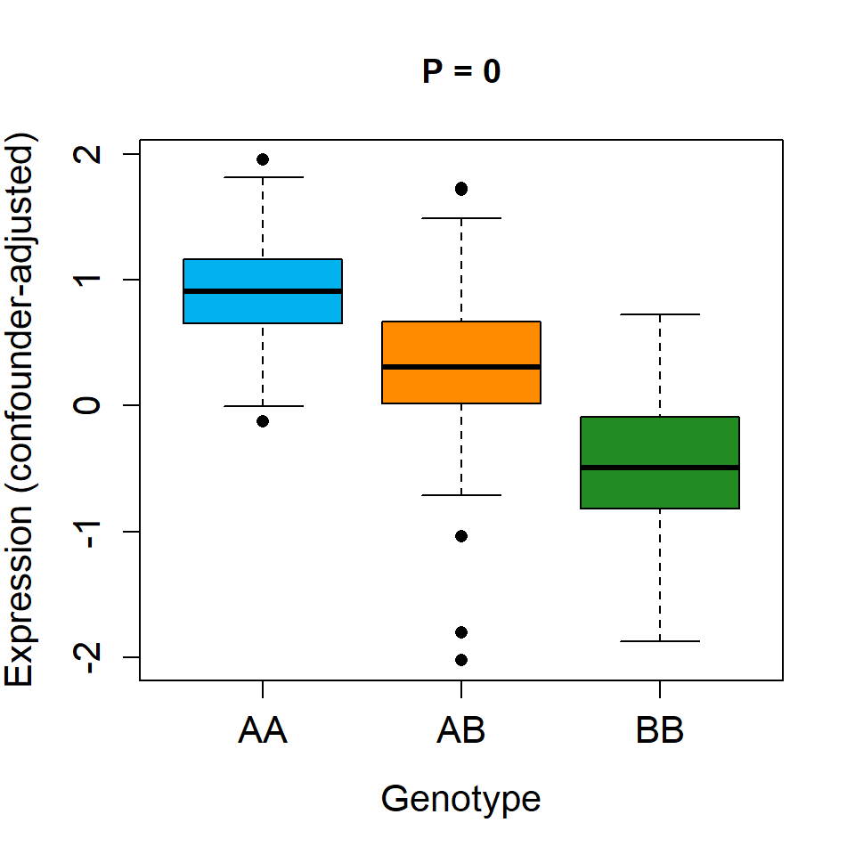

```r
names(ols_out)
```

```
#> [1] "lm_out"    "out_df"    "res_trim"  "cooksd"    "prop_trim"
```

```r
# Model estimates
summary(ols_out$lm_out)
```

```
#>
#> Call:
#> lm(formula = YY_final ~ ., data = fin_XX)
#>
#> Residuals:
#>      Min       1Q   Median       3Q      Max
#> -2.21073 -0.32724  0.01604  0.40286  1.53527
#>
#> Coefficients:
#>             Estimate Std. Error t value Pr(>|t|)
#> (Intercept)  1.37255    0.07329  18.728   <2e-16 ***
#> X2           0.29801    0.03164   9.418   <2e-16 ***
#> X3          -0.74058    0.06288 -11.777   <2e-16 ***
#> X4           0.32274    0.03166  10.193   <2e-16 ***
#> X5          -0.33828    0.03149 -10.742   <2e-16 ***
#> SNP         -0.75528    0.04456 -16.950   <2e-16 ***
#> ---
#> Signif. codes:  0 '***' 0.001 '**' 0.01 '*' 0.05 '.' 0.1 ' ' 1
#>
#> Residual standard error: 0.5421 on 294 degrees of freedom
#> Multiple R-squared:  0.7023, Adjusted R-squared:  0.6973
#> F-statistic: 138.7 on 5 and 294 DF,  p-value: < 2.2e-16
```

```r
# Effect sizes and hypothesis test
ols_out$out_df
```

```
#>     CT       EST         SE PVAL
#> 1 Bulk -0.755285 0.04455894    0
```

Similar to CSeQTL’s bulk testing, we have a false positive bulk eQTL.

### Cell type-specific eQTLs

The code below will test for cell type-specific eQTLs with OLS.

```r
ols_out = CSeQTL_linearTest(input = sim$dat,XX = sim$XX,
  RHO = sim$true_RHO,SNP = sim$true_SNP,MARG = FALSE)
```

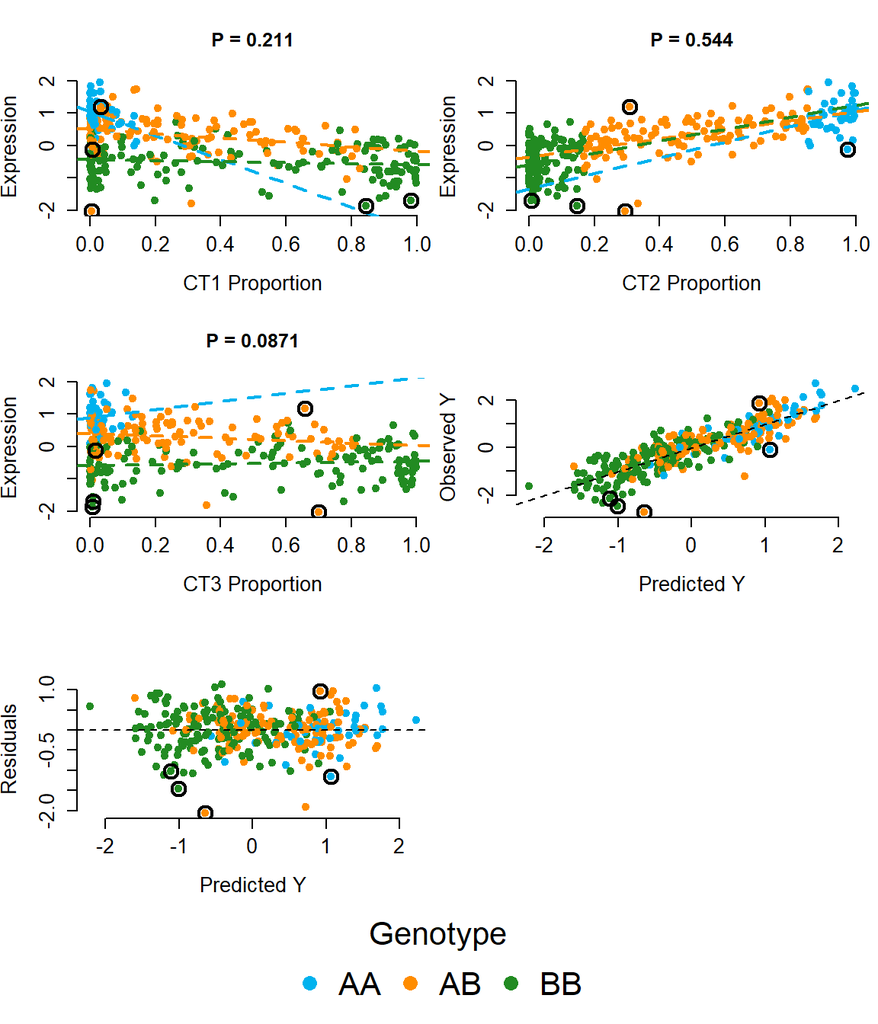

```r
names(ols_out)
```

```
#> [1] "lm_out"    "out_df"    "res_trim"  "cooksd"    "prop_trim"
```

```r
# Model estimates
summary(ols_out$lm_out)
```

```
#>
#> Call:
#> lm(formula = YY_final ~ ., data = fin_XX)
#>
#> Residuals:
#>      Min       1Q   Median       3Q      Max
#> -2.06584 -0.29634  0.02862  0.32315  1.13060
#>
#> Coefficients:
#>             Estimate Std. Error t value Pr(>|t|)
#> (Intercept)  0.09094    0.29950   0.304   0.7616
#> X2           0.30044    0.02918  10.295   <2e-16 ***
#> X3          -0.74198    0.05813 -12.764   <2e-16 ***
#> X4           0.32697    0.02922  11.191   <2e-16 ***
#> X5          -0.32246    0.02913 -11.069   <2e-16 ***
#> SNP         -0.19956    0.15931  -1.253   0.2113
#> CT2          1.27072    0.32218   3.944   0.0001 ***
#> CT3          0.29099    0.42680   0.682   0.4959
#> SNP_CT2      0.28175    0.18197   1.548   0.1226
#> SNP_CT3     -0.08092    0.23251  -0.348   0.7281
#> ---
#> Signif. codes:  0 '***' 0.001 '**' 0.01 '*' 0.05 '.' 0.1 ' ' 1
#>
#> Residual standard error: 0.4995 on 290 degrees of freedom
#> Multiple R-squared:  0.7508, Adjusted R-squared:  0.743
#> F-statistic: 97.07 on 9 and 290 DF,  p-value: < 2.2e-16
```

```r
# Effect sizes and hypothesis tests
ols_out$out_df
```

```
#>    CT         EST        SE       PVAL
#> 1 CT1 -0.19955716 0.1593063 0.21133755
#> 2 CT2  0.08219402 0.1352272 0.54378148
#> 3 CT3 -0.28047913 0.1633836 0.08710334
```

# Future Sections to create

- Trimming
- Sample data for eQTL mapping per gene and multiple SNPs

# References

Little, P., Liu, S., Zhabotynsky, V., Li, Y., Lin, D.-Y., & Sun, W. (2023). A computational method for cell type-specific expression quantitative trait loci mapping using bulk RNA-seq data. *Nature Communications*, *14*(1), 3030.

Shabalin, A. A. (2012). Matrix eQTL: Ultra fast eQTL analysis via large matrix operations. *Bioinformatics*, *28*(10), 1353–1358.

Sun, W. (2012). A statistical framework for eQTL mapping using RNA-seq data. *Biometrics*, *68*(1), 1–11.